# Labelled Columns with Frictionless-R

Kyle Husmann

2023-11-28

## Introduction

I’ve put together this vignette to demo a proof of concept implementation of value labels for `frictionless-r`. My goal has been a simple, ergonomic API for working with value (and missing) labels in frictionless that generalizes the concepts introduced by SAS, Stata, SPSS, et al., and can be used with tidyverse wrangling functions in powerfully expressive ways. Luckily there was a lot of existing work in this area I was able to build on!

NOTE THAT THIS IMPLEMENTATION IS HIGHLY EXPERIMENTAL! There’s a lot to still implement (e.g. ordered factors). Even more, I’m still learning all the quirks of R’s class system and how `tidyverse` augments it. This is a proof- of-concept designed to explore these ideas and get some early feedback on these directions that I’m exploring.

For all the examples in this text, I will use the example datapackage loaded below (and linked here):

```r
library(tidyverse)
library(frictionless)
library(jsonlite)
library(haven)

pkg <- read_package("example-pkg/datapackage.json")
```

```
## Please make sure you have the right to access data from this Data Package for your intended use.
## Follow applicable norms or requirements to credit the dataset and its authors.
```

## Background

Value labels are extra metadata attached to certain values of a variable in a dataset. For example, a question on a survey asking an individual to rate how good their day was on a scale from 1-5 might include labels alongside the number to help “calibrate” the numeric responses for the respondent (e.g. 1 = Very bad, 2 = Bad, 3 = Neutral, 4 = Good, 5 = Very good). Sometimes these labels are referred to as “anchors” for the scale, especially when they label the scale’s extrema (e.g. a 10-point pain scale with 0 = No pain, and 9 = Worst pain imaginable).

In the [recently accepted frictionless extension](https://github.com/frictionlessdata/specs/pull/844), proposed by Phil Schumm, value labels can be added to any variable type via the `enumLabels` schema field property. The `enumOrdered` property is was also introduced to distinguish ordinal vs categorical variables. With these properties, the aforementioned “good day scale” and “pain scale” can be represented as follows:

```r
get_schema(pkg, "example1")$fields[[1]] %>%
  toJSON(pretty=TRUE, auto_unbox=TRUE)
```

```
## {
##   "name": "day_scale",
##   "description": "On a scale from 1-5, how was your day?",
##   "type": "integer",
##   "constraints": {
##     "enum": [1, 2, 3, 4, 5]
##   },
##   "enumOrdered": true,
##   "enumLabels": {
##     "1": "Very bad",
##     "2": "Bad",
##     "3": "Neutral",
##     "4": "Good",
##     "5": "Very good"
##   }
## }
```

```r
get_schema(pkg, "example1")$fields[[2]] %>%
  toJSON(pretty=TRUE, auto_unbox=TRUE)
```

```
## {
##   "name": "pain_scale",
##   "description": "On a scale from 0-9, how do you rate your pain?",
##   "type": "integer",
##   "constraints": {
##     "enum": [0, 1, 2, 3, 4, 5, 6, 7, 8, 9]
##   },
##   "enumOrdered": true,
##   "enumLabels": {
##     "0": "No pain",
##     "9": "Worst pain imaginable"
##   }
## }
```

Although the `enumLabels` property has `enum` in its name, it is not limited to types with enum constraints – it can be used to provide labels for any type. for example, the following field definition is also valid:

```r
get_schema(pkg, "example1")$fields[[3]] %>%
  toJSON(pretty=TRUE, auto_unbox=TRUE)
```

```
## {
##   "name": "pick_a_number",
##   "description": "Pick a number!",
##   "type": "integer",
##   "enumLabels": {
##     "7": "Magic number"
##   }
## }
```

(By contrast, the `enumOrdered` only applies to fields with `enum` constraints. I think this is a little confusing, and might be worth revisiting in the standard extension at some point.)

(Note that my implementation here does not yet support `enumOrdered`, but it should be easy to add.)

## Frictionless-r implementation

Here’s what it looks like when the above three fields are loaded into a dataframe with my frictionless-r implementation (found in my fork on the [`categorical-ext` branch](https://github.com/khusmann/frictionless-r/tree/categorical-ext)):

```r
(example1 <- read_resource(pkg, "example1"))
```

```
## # A tibble: 10 × 3
##    day_scale     pain_scale                pick_a_number
##    <fct+lbl>     <fct+lbl>                 <dbl+lbl>
##  1 2 [Bad]       0 [No pain]               10.9
##  2 5 [Very good] 4                          3.72
##  3 2 [Bad]       3                         10.9
##  4 4 [Good]      8                         11.1
##  5 1 [Very bad]  7                          7 [Magic number]
##  6 2 [Bad]       7                         18.8
##  7 5 [Very good] 1                          8.54
##  8 5 [Very good] 9 [Worst pain imaginable] 14.5
##  9 3 [Neutral]   9 [Worst pain imaginable]  2.69
## 10 4 [Good]      1                         19.5
```

As you can see, the `tibble` displays both values and their labels. You can’t see it in the rendered Rmd, but in the R console, the labels are a grayed out color to help differentiate them from the actual values.

This behavior accomplished by way of the `haven` package in the `tidyverse` universe. `haven` provides the `haven_labelled` class that enables numeric and character vectors to be augmented by labels. A limitation of the `haven_labelled` class, however, is that it can only be used with numeric and character vectors, because it was originally designed as a compatibility layer for the variable types found in SPSS, Stata, and SAS.

This behavior is fine for loading numeric fields with labels in frictionless schemas, like `pick_a_number`. For labeled enum types, like `day_scale` and `pain_scale` however, conversion to labelled numerics does not preserve the `enum` constraint in its type. As you can see above, to address this, I extended the `haven_labelled` class into a new `frictionless_labelled_fct` class that also support factors as a base type (denoted by the `fct+lbl` tibble header).

The advantage of this approach is that when we remove the labels using `haven::zap_labels`, we get factor types for these enum fields, instead of raw numeric:

```r
zap_labels(example1)
```

```
## # A tibble: 10 × 3
##    day_scale pain_scale pick_a_number
##    <fct>     <fct>              <dbl>
##  1 2         0                  10.9
##  2 5         4                   3.72
##  3 2         3                  10.9
##  4 4         8                  11.1
##  5 1         7                   7
##  6 2         7                  18.8
##  7 5         1                   8.54
##  8 5         9                  14.5
##  9 3         9                   2.69
## 10 4         1                  19.5
```

This means that all the levels of the enum described in the schema are properly present in the factor levels, even if they don’t all show up in the data:

```r
levels(zap_labels(example1)$day_scale)
```

```
## [1] "1" "2" "3" "4" "5"
```

Had we used only a labelled numeric, removing the labels would have given us a raw numeric type that we’d have to turn into a factor… and would have required another visit to the field’s schema to know what the levels were supposed to be. Instead, by loading all this information up front into the custom type, manipulations become much more fluid.

## Working with value labels

`haven` provides `as_factor` for converting values to labels. By default, it will keep the original values around as levels:

```r
as_factor(example1)
```

```
## # A tibble: 10 × 3
##    day_scale pain_scale            pick_a_number
##    <fct>     <fct>                 <fct>
##  1 Bad       No pain               10.8954930456821
##  2 Very good 4                     3.7223543941509
##  3 Bad       3                     10.879648667993
##  4 Good      8                     11.0768237111624
##  5 Very bad  7                     Magic number
##  6 Bad       7                     18.8374477296602
##  7 Very good 1                     8.54474583012052
##  8 Very good Worst pain imaginable 14.5098809765186
##  9 Neutral   Worst pain imaginable 2.69382031448185
## 10 Good      1                     19.5025003356859
```

Alternatively, unlabeled values can be marked NA with the `levels="labels` option:

```r
as_factor(example1, levels="labels")
```

```
## # A tibble: 10 × 3
##    day_scale pain_scale            pick_a_number
##    <fct>     <fct>                 <fct>
##  1 Bad       No pain               <NA>
##  2 Very good <NA>                  <NA>
##  3 Bad       <NA>                  <NA>
##  4 Good      <NA>                  <NA>
##  5 Very bad  <NA>                  Magic number
##  6 Bad       <NA>                  <NA>
##  7 Very good <NA>                  <NA>
##  8 Very good Worst pain imaginable <NA>
##  9 Neutral   Worst pain imaginable <NA>
## 10 Good      <NA>                  <NA>
```

Between `zap_labels()` and `as_factor()` working with values or labels becomes a breeze:

```r
example1 %>%
  filter(pain_scale == "9") # Note -- this is a string comparison for now, but I plan to fix later
```

```
## # A tibble: 2 × 3
##   day_scale     pain_scale                pick_a_number
##   <fct+lbl>     <fct+lbl>                 <dbl+lbl>
## 1 5 [Very good] 9 [Worst pain imaginable] 14.5
## 2 3 [Neutral]   9 [Worst pain imaginable]  2.69
```

```r
example1 %>%
  filter(as_factor(pain_scale) == "Worst pain imaginable")
```

```
## # A tibble: 2 × 3
##   day_scale     pain_scale                pick_a_number
##   <fct+lbl>     <fct+lbl>                 <dbl+lbl>
## 1 5 [Very good] 9 [Worst pain imaginable] 14.5
## 2 3 [Neutral]   9 [Worst pain imaginable]  2.69
```

More examples:

```r
example1 %>%
  group_by(day_scale) %>%
  summarize(
    avg_pain = mean(as.numeric(as.character(pain_scale))) # Note -- this is awkward for now (see above comment about strings)
  )
```

```
## # A tibble: 5 × 2
##   day_scale     avg_pain
##   <fct+lbl>        <dbl>
## 1 1 [Very bad]      7
## 2 2 [Bad]           3.33
## 3 3 [Neutral]       9
## 4 4 [Good]          4.5
## 5 5 [Very good]     4.67
```

This is especially nice for graphing. (Note the x axis labels):

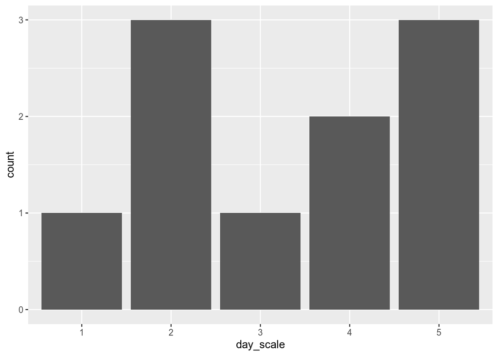

```r
example1 %>%
  ggplot(aes(day_scale)) +
  geom_histogram(stat="count")
```

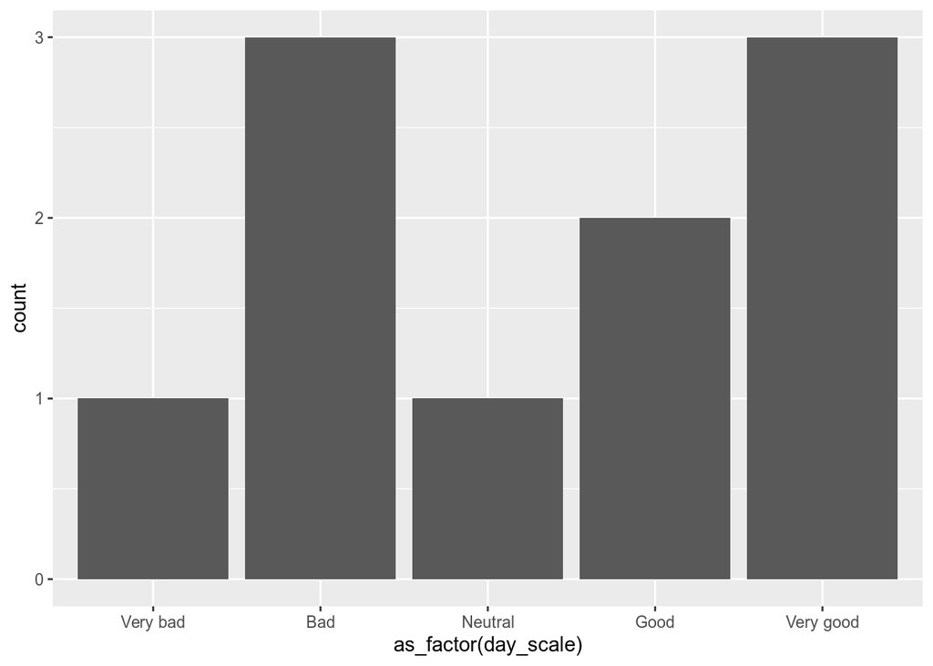

```r
example1 %>%
  ggplot(aes(as_factor(day_scale))) +
  geom_histogram(stat="count")
```

The downside of `as_factor` and `zap_labels` is they lose the label attribute information. I’ve been experimenting with an alternative approach that allows for round-trip conversions between labels and values. For now, I’m calling the function `apply_labels()`:

```r
apply_labels(example1)
```

```
## # A tibble: 10 × 3
##    day_scale     pain_scale                pick_a_number
##    <fct+lbl>     <fct+lbl>                 <chr+lbl>
##  1 Bad [2]       No pain [0]               10.8954930456821
##  2 Very good [5] 4                         3.7223543941509
##  3 Bad [2]       3                         10.879648667993
##  4 Good [4]      8                         11.0768237111624
##  5 Very bad [1]  7                         Magic number [7]
##  6 Bad [2]       7                         18.8374477296602
##  7 Very good [5] 1                         8.54474583012052
##  8 Very good [5] Worst pain imaginable [9] 14.5098809765186
##  9 Neutral [3]   Worst pain imaginable [9] 2.69382031448185
## 10 Good [4]      1                         19.5025003356859
```

```r
# Round trip
apply_labels(apply_labels(example1))
```

```
## # A tibble: 10 × 3
##    day_scale     pain_scale                pick_a_number
##    <fct+lbl>     <fct+lbl>                 <chr+lbl>
##  1 2 [Bad]       0 [No pain]               10.8954930456821
##  2 5 [Very good] 4                         3.7223543941509
##  3 2 [Bad]       3                         10.879648667993
##  4 4 [Good]      8                         11.0768237111624
##  5 1 [Very bad]  7                         7 [Magic number]
##  6 2 [Bad]       7                         18.8374477296602
##  7 5 [Very good] 1                         8.54474583012052
##  8 5 [Very good] 9 [Worst pain imaginable] 14.5098809765186
##  9 3 [Neutral]   9 [Worst pain imaginable] 2.69382031448185
## 10 4 [Good]      1                         19.5025003356859
```

## Variable labels

As an added bonus, `haven_labelled` also stores “variable labels”, a string of metadata to hold information about fields. We can have `frictionless-r` load metadata into this attribute as well. In the present implementation, I have it grab data from the `description` field property, so this information is displayed when viewing the table with `View()`.

Other packages like [`codebookr`](https://brad-cannell.github.io/codebookr/) and [`labelled`](https://cran.r-project.org/web/packages/labelled/vignettes/intro_labelled.html) use this info to generate codebooks:

```r
library(labelled)
library(gt)
generate_dictionary(example1) %>%
  gt()
```

| pos | variable | label | col_type | levels | value_labels |
| --- | --- | --- | --- | --- | --- |
| 1 | day_scale | On a scale from 1-5, how was your day? | fct+lbl | 1, 2, 3, 4, 5 | 1, 2, 3, 4, 5 |
| 2 | pain_scale | On a scale from 0-9, how do you rate your pain? | fct+lbl | 0, 1, 2, 3, 4, 5, 6, 7, 8, 9 | 0, 9 |
| 3 | pick_a_number | Pick a number! | dbl+lbl |  | 7 |

I’m working on my own interactive codebook generator as well, stay tuned!

## Missing values

Value labels in SAS, Stata, SPSS sometimes add metadata to missing values as well (e.g. missing reasons). Although the `haven` package provides additional functionality for working with labelled missingness, its approach is very much tied to the specific quriks of SAS, Stata, and SPSS’ implementations.

I have found that simply loading missingness as separate columns provides an implementation-agnostic way of loading and working with labelled missingness. I describe this approach in a separate vignette.

This approach for working with missing reasons is highly synergistic with the value labels I’ve described in this document. It gives us a simple general interface by which we can work with SAS, SPSS, and Stata formatted data in R, and easily convert between their styles of missingness representations. I will talk about this more in a future vignette.

Thanks for reading this far! I appreciate your thoughts and feedback.